# Elektromagnetika

## (Introduction to Electromagnetics and Electromagnetic Fields)

### Dr. Ir. Marzuki Sinambela, S.Kom, M.T

## Konsep Dasar

- Hukum Newton: f = ma
- Energi Kinetik: 1/2 mv^2
- Energi Foton: E = hf
- Medan listrik dan magnet dijelaskan oleh Hukum Lorentz

Elektromagnetika mempelajari perilaku muatan listrik dalam ruang hampa maupun materi. Fenomena ini dijelaskan oleh:

Hukum Lorentz Persamaan Maxwell

Bidang ini sangat penting dalam teknik elektro karena menjadi dasar:

Listrik Komunikasi Elektronika Komputer dan AI

## Pengukuran medan listrik dan medan magnet dengan menggunakan muatan listrik.

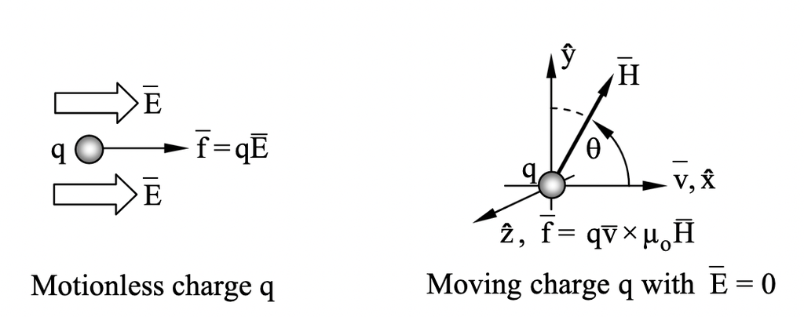

Gambar tersebut menunjukkan dua kondisi gaya pada muatan listrik q dalam medan elektromagnetik: Muatan diam dalam medan listrik (E⃗) Pada bagian kiri, muatan q berada dalam keadaan diam dan hanya dipengaruhi oleh medan listrik. Gaya yang bekerja diberikan oleh f⃗=qE⃗. Ini menunjukkan bahwa medan listrik dapat diukur melalui gaya yang ditimbulkannya pada muatan uji, dan arahnya searah dengan medan untuk muatan positif.

Muatan bergerak dalam medan magnet (H⃗) tanpa medan listrik Pada bagian kanan, muatan bergerak dengan kecepatan v dalam medan magnet. Gaya yang timbul adalah gaya Lorentz: f⃗=qv⃗×μ0H⃗. Gaya ini tegak lurus terhadap arah kecepatan dan medan magnet, sehingga tidak mengubah besar kecepatan, hanya arah geraknya.

Sifat dan pengukuran medan elektromagnetik:

Medan listrik diukur dari gaya pada muatan diam. Medan magnet diukur dari gaya pada muatan yang bergerak. Keduanya bersifat vektor (memiliki arah dan besar) dan saling terkait dalam fenomena elektromagnetik. Medan elektromagnetik memengaruhi gerak partikel bermuatan, baik dalam kondisi diam maupun bergerak.

Tidak ada metode fisik lain untuk mendeteksi atau mengukur medan listrik statis atau medan magnet; hanya dapat mengukur gaya yang bekerja pada muatan atau benda bermuatan, atau mengukur dampak dari gaya tersebut, misalnya dengan mengukur arus yang dihasilkannya. Akan sangat membantu jika memiliki gambaran fisik sederhana tentang bagaimana medan berperilaku sehingga bentuk dan perilakunya dapat ditebak atau dipahami secara kasar tanpa harus menggunakan solusi matematis. Gambaran fisik semacam itu dapat berguna meskipun sama sekali tidak terkait dengan kenyataan, asalkan gambaran tersebut dapat memprediksi semua pengamatan dengan cara yang sederhana. Karena hukum gaya Lorentz ditambah persamaan Maxwell menjelaskan pada dasarnya semua perilaku elektromagnetik non-relativistik dan non-kuantum dengan cara yang sederhana menggunakan medan ⎯E dan ⎯H, kita hanya perlu memastikan bagaimana ⎯E dan ⎯H berperilaku dengan distribusi muatan q tertentu yang stasioner atau bergerak.

## Garis-garis medan listrik di antara dua silinder konduktor.

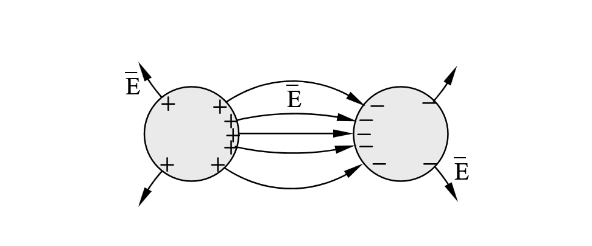

Gambar diatas menggambarkan hasil dari tolak-menolak antar garis medan ini, meskipun garis-garis tersebut menarik muatan-muatan berlawanan pada silinder konduktor ke arah satu sama lain. Nanti kita akan melihat bahwa garis-garis medan listrik semacam itu selalu tegak lurus terhadap permukaan konduktor sempurna. Meskipun garis-garis ini digambarkan sebagai titik-titik terpisah, sebenarnya garis-garis tersebut merupakan suatu kontinuum, meskipun hanya melibatkan dua muatan.

Intuisi yang sama berlaku untuk garis medan magnet⎯H. Misalnya, Gambar diatas akan berlaku jika kedua silinder tersebut mewakili kutub utara (+) dan selatan (-) dari sebuah magnet, dan jika⎯E berubah menjadi⎯H, meskipun⎯H tidak harus muncul secara tegak lurus sempurna terhadap permukaan magnet. Dalam kasus ini pula, garis-garis medan akan secara fisik menarik kedua kutub magnet tersebut satu sama lain. Baik motor listrik maupun motor magnetik dapat digerakkan menggunakan baik gaya tarik sepanjang garis medan maupun gaya tolak lateral antar garis, tergantung pada desain motor, sebagaimana dibahas nanti

### Contoh Soal 1 (energi → kecepatan (mekanika))

Sebuah baterai mobil listrik 1 kWh dapat mempercepat mobil bermassa 1000 kg hingga kecepatan maksimum berapa?

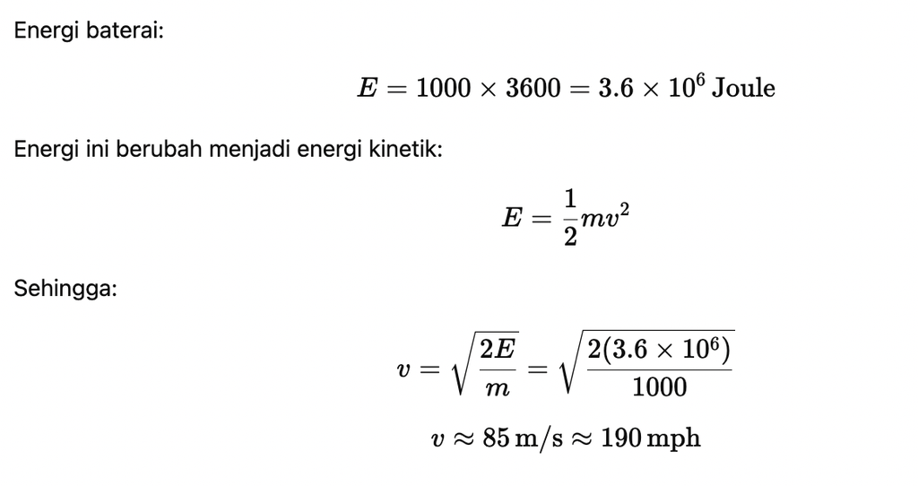

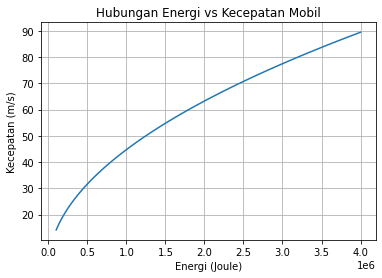

```python
import numpy as np
import matplotlib.pyplot as plt

# massa mobil
m = 1000  # kg

# range energi
E = np.linspace(1e5, 4e6, 100)

# hitung kecepatan
v = np.sqrt(2 * E / m)

plt.plot(E, v)
plt.title("Hubungan Energi vs Kecepatan Mobil")
plt.xlabel("Energi (Joule)")
plt.ylabel("Kecepatan (m/s)")
plt.grid()
plt.show()
```

## Soal 2 (energi gelombang → jumlah foton (fisika kuantum))

Jika energi matahari ≈ 1 kW/m² dan panjang gelombang λ = 5×10⁻⁷ m, berapa jumlah foton per detik?

[figure not shown]

## Gaya serta pengukuran dan sifat medan elektromagnetik

Beberapa contoh sederhana menggambarkan medan listrik yang umum untuk distribusi muatan yang lazim, serta bagaimana hukum Gauss dapat digunakan untuk menghitung medan-medan tersebut. Pertama, pertimbangkan sebuah bola berjari-jari R yang diisi secara merata dengan muatan berdensitas ρo [C/m³], seperti yang digambarkan pada Gambar dibawa ini.

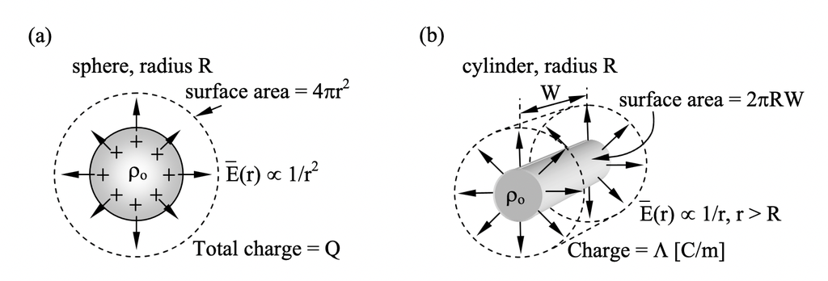

Medan listrik⎯E(r) yang dihasilkan oleh bola dan silinder yang bermuatan seragam.

## Medan listrik di antara dua pelat sejajar.

Geometri sederhana ketiga adalah geometri pelat konduktor paralel tak terhingga yang bermuatan dan dipisahkan oleh jarak d, di mana permukaan bagian dalam pelat atas dan bawah masing-masing memiliki kepadatan muatan permukaan +ρs dan -ρs [C/m²], seperti yang digambarkan pada Gambar untuk pelat berukuran terbatas. Keseragaman pelat tak terhingga terhadap x, y, dan φ mensyaratkan bahwa solusi ⎯E juga tidak bergantung pada x, y, dan φ. Simetri terhadap φ mensyaratkan bahwa ⎯E mengarah ke arah ±z. Hukum Hukum Gauss kemudian mensyaratkan bahwa⎯E harus bebas dari z karena integral dari⎯D di atas permukaan atas dan bawah volume persegi panjang mana pun yang terletak di antara pelat harus saling meniadakan karena tidak ada muatan di dalam volume tersebut dan tidak ada⎯D yang melewati sisinya.

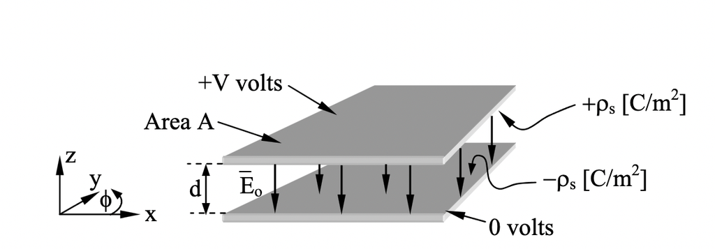